# Casos confirmados e óbitos por covid-19 na Bahia

https://github.com/jonates

04/08/2020

Todos os gráficos foram gerados utilizando os microdados públicos dos casos notificados de covid-19 na Bahia, disponibilizado diariamente pela Secretaria de Saúde da Bahia - SESAB, no portal https://bi.saude.ba.gov.br/transparencia/ desde o dia 15 de julho de 2020.

Os scripts, escritos na linguagem **R** e **Markdown** estão disponíveis no repositório: https://github.com/jonates/report_covid19_BA. Este repositório é público. O autor aguarda que surjam contribuições tanto de ajustes e melhorias nos scripts, quanto acréscimos de novas visualizações.

Como qualquer conjunto de dados, existem erros em alguns registros do conjunto de dados, bem como valores ausentes. Assim, na ausência da data do início do sintoma foi considerado a data do exame, e, na ausência dessas 2 datas, foi considerada a data da notificação.

A semana epidemiológica foi definida com a função EpiWeek da biblioteca Epitools.

Vale ressaltar que este arquivo parte de iniciativa acadêmica, passível de ajustes, e, não é documento oficial do Governo da Bahia.

## **1 - Séries históricas do COVID-19 na Bahia**

**Figura 1.** Casos novos de COVID-19, por data de início de sintoma (e média móvel de 7 dias), Bahia, 2020.

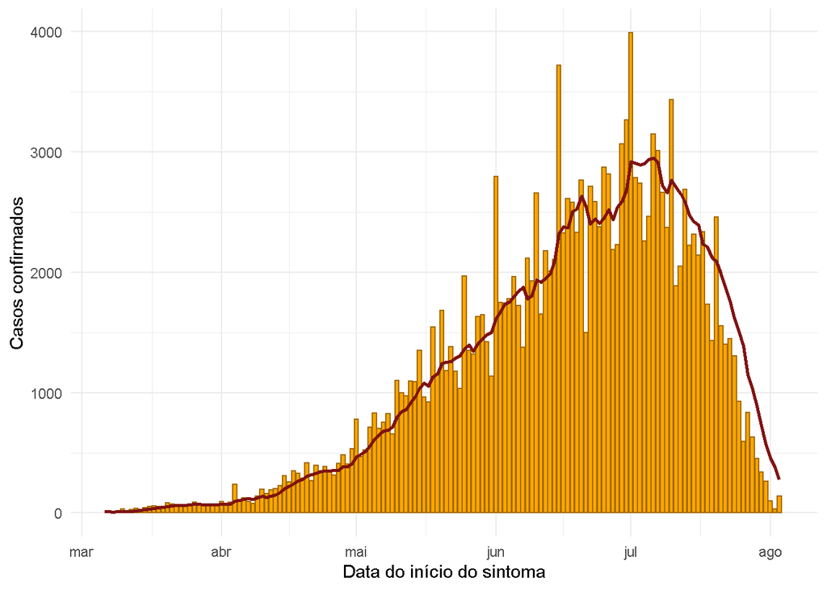

**Figura 2.** Óbitos por COVID-19, por data do óbito (e média móvel de 7 dias), Bahia, 2020.

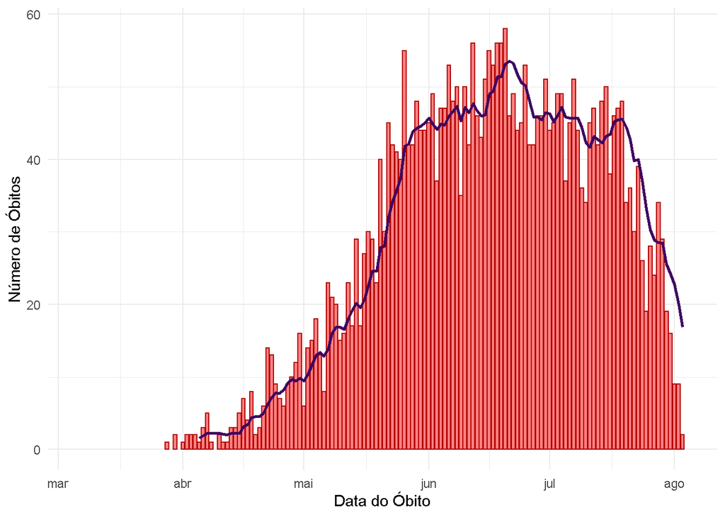

**Figura 3.** Óbitos por COVID-19, por semana epidemiológica, Bahia, 2020.

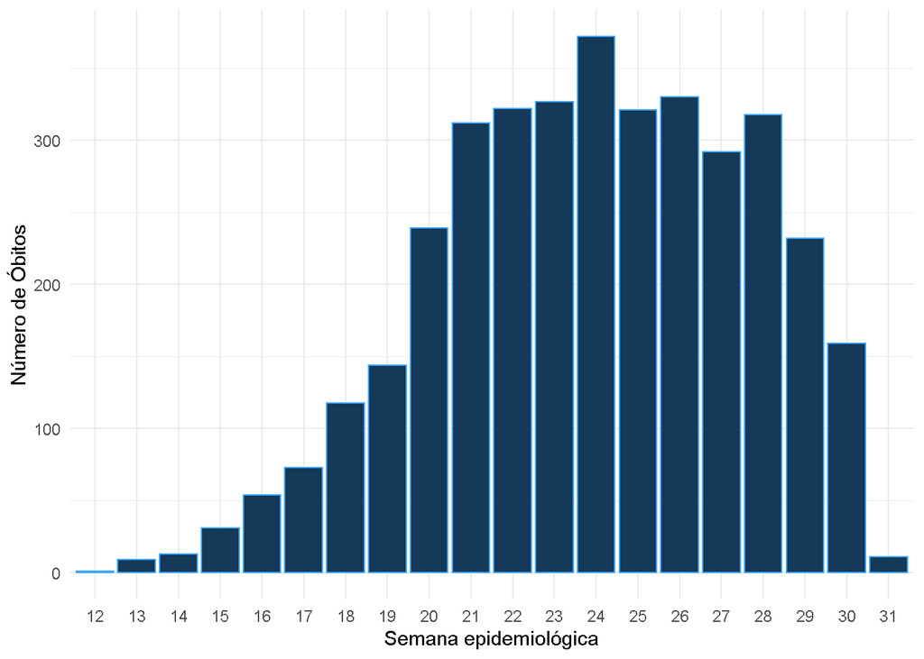

## **2 - Séries históricas do COVID-19 por macrorregiões da Bahia**

### **2.1 - Séries históricas do COVID-19 no Centro-leste da Bahia**

**Figura 4.** Casos novos de COVID-19, por data de início de sintoma (e média móvel de 7 dias),, Centro-leste da Bahia, 2020.

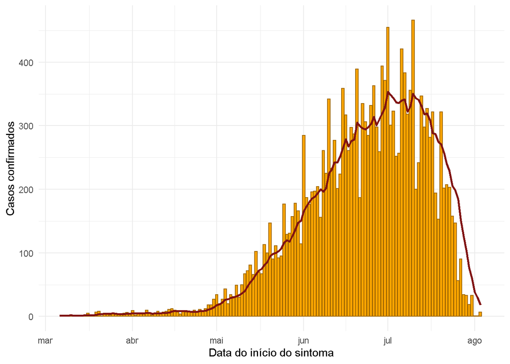

**Figura 5.** Óbitos por COVID-19, por semana epidemiológica, Centro-leste da Bahia, 2020.

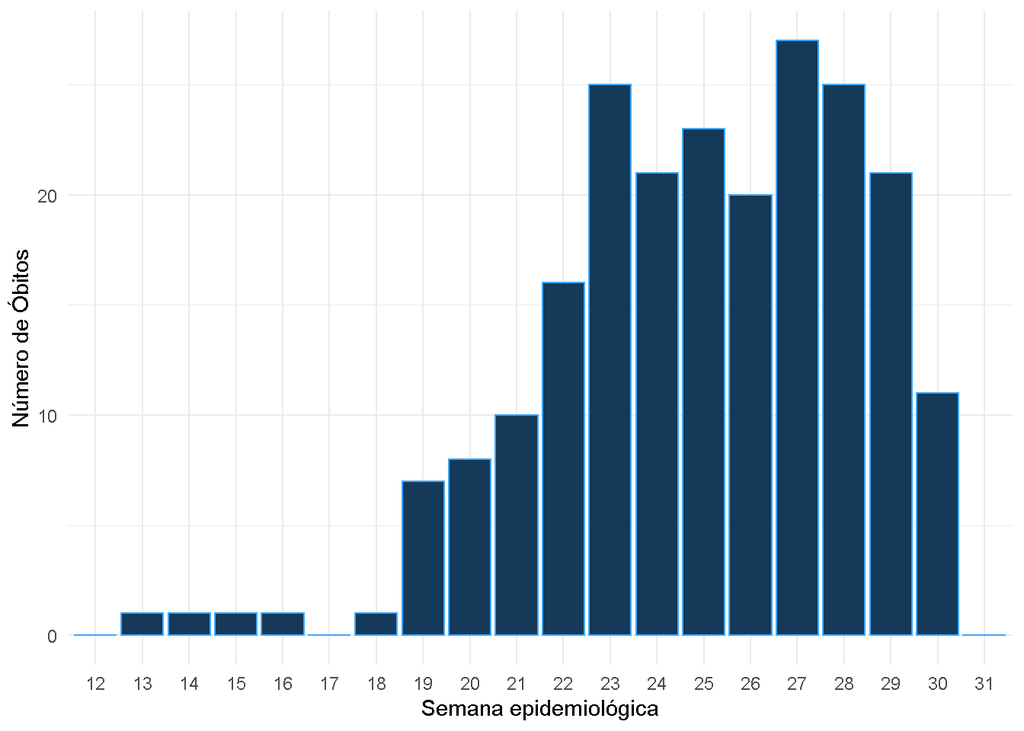

### **2.2 - Séries históricas do COVID-19 no Centro-norte da Bahia**

**Figura 6.** Casos novos de COVID-19, por data de início de sintoma (e média móvel de 7 dias), Centro-norte da Bahia, 2020.

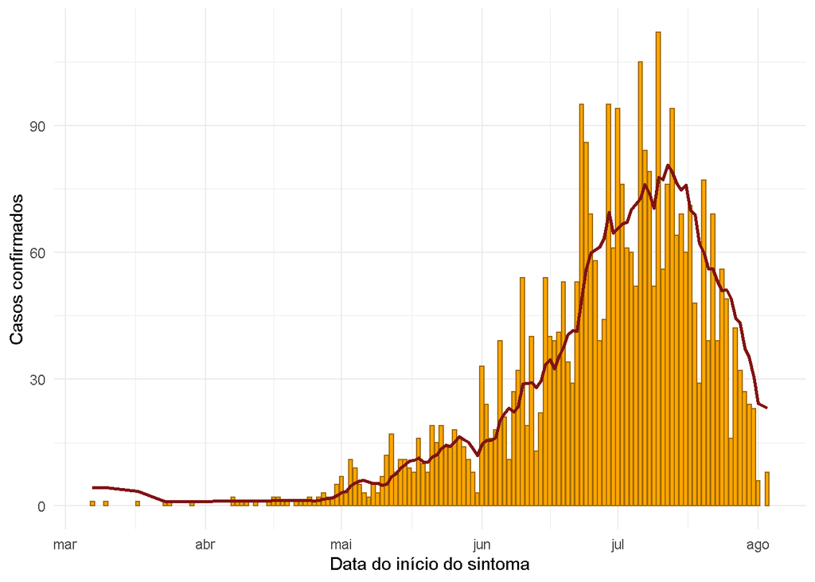

**Figura 7.** Óbitos por COVID-19, por semana epidemiológica, Centro-norte da Bahia, 2020.

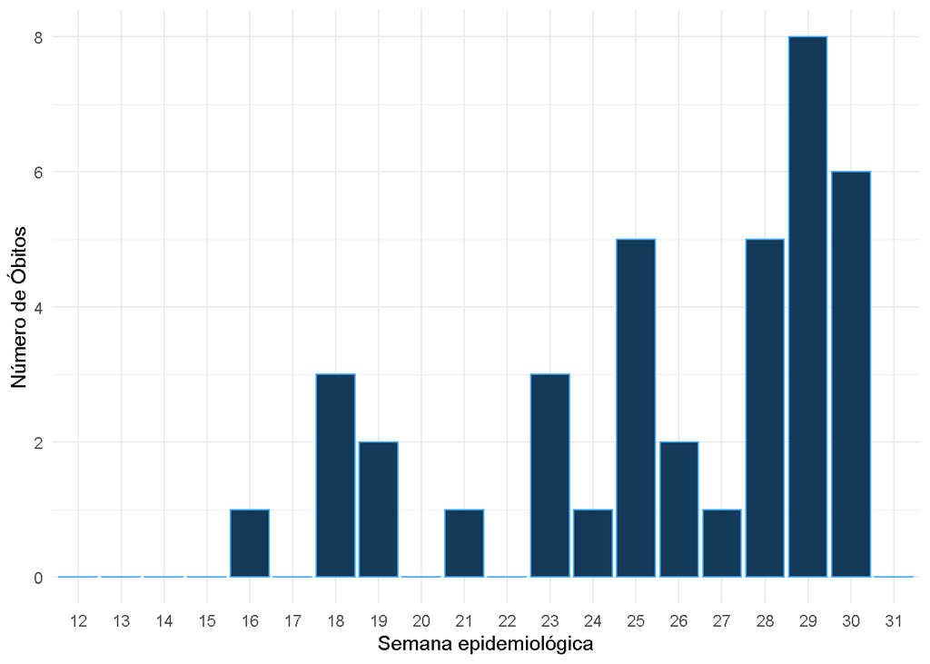

### **2.3 - Séries históricas do COVID-19 no Extremo sul da Bahia**

**Figura 8.** Casos novos de COVID-19, por data de início de sintoma (e média móvel de 7 dias), Extremo sul da Bahia, 2020.

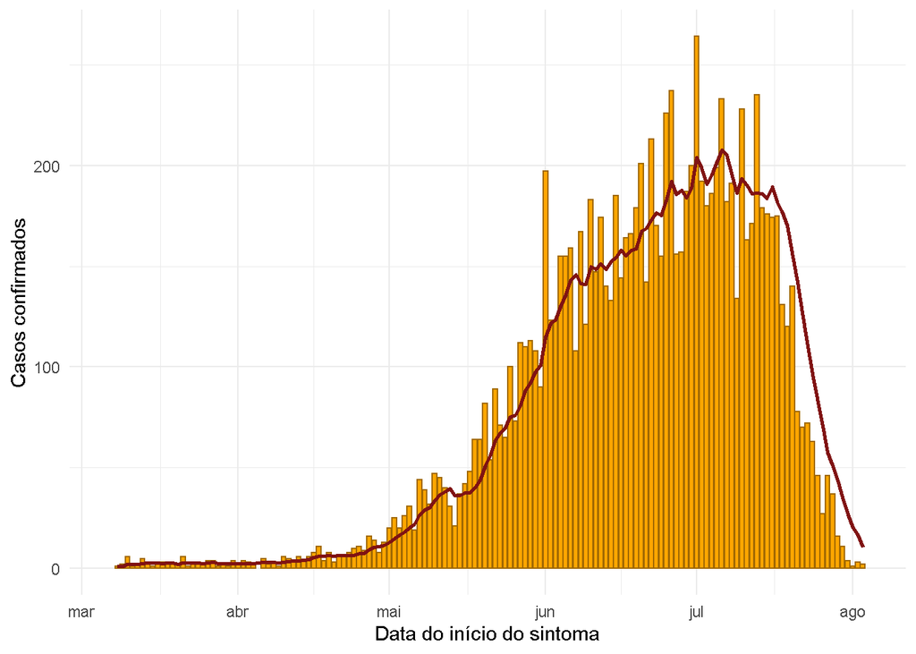

**Figura 9.** Óbitos por COVID-19, por semana epidemiológica, Extremo sul da Bahia, 2020.

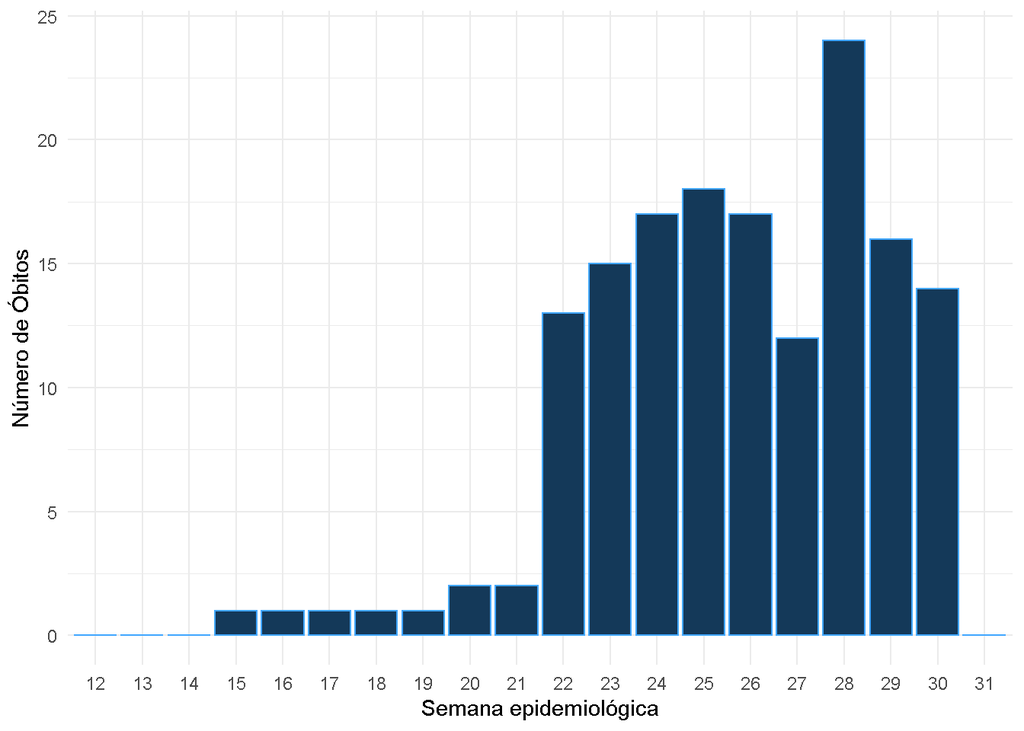

### **2.4 - Séries históricas do COVID-19 no Leste da Bahia**

**Figura 10.** Casos novos de COVID-19, por data de início de sintoma (e média móvel de 7 dias), Leste da Bahia, 2020.

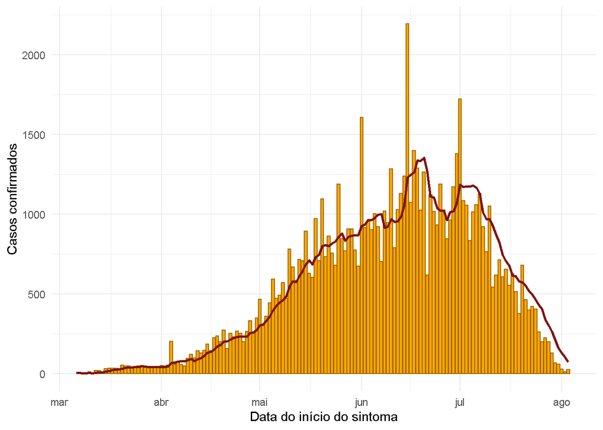

**Figura 11.** Óbitos por COVID-19, por semana epidemiológica, Leste da Bahia, 2020.

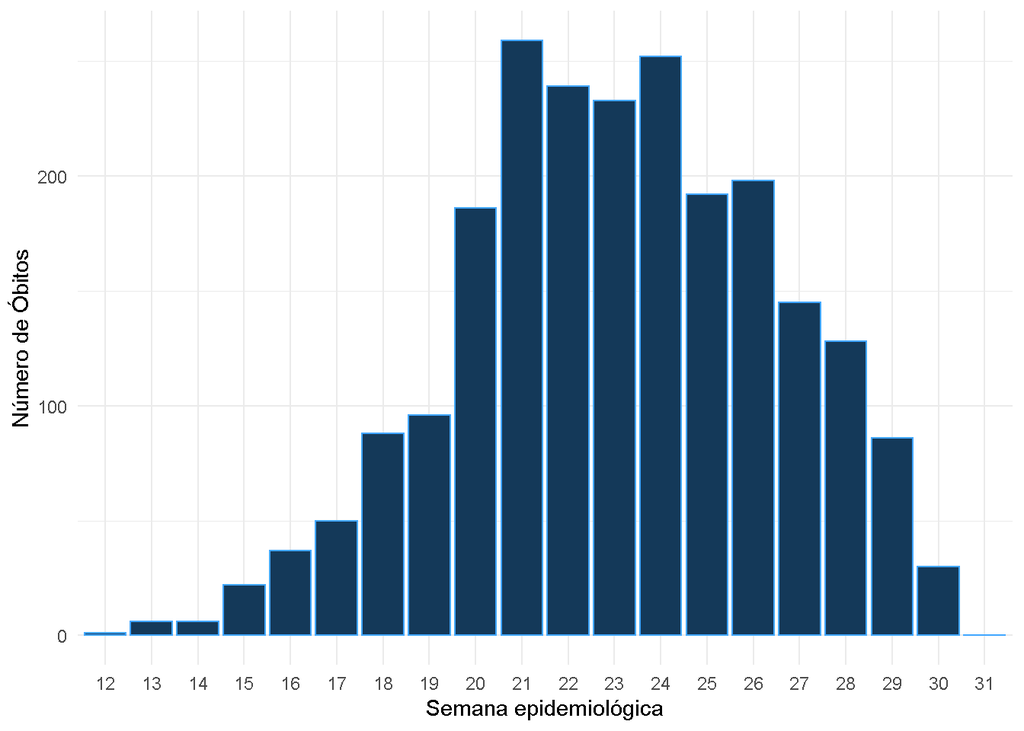

### **2.5 - Séries históricas do COVID-19 no Nordeste da Bahia**

**Figura 12.** Casos novos de COVID-19, por data de início de sintoma (e média móvel de 7 dias), Nordeste da Bahia, 2020.

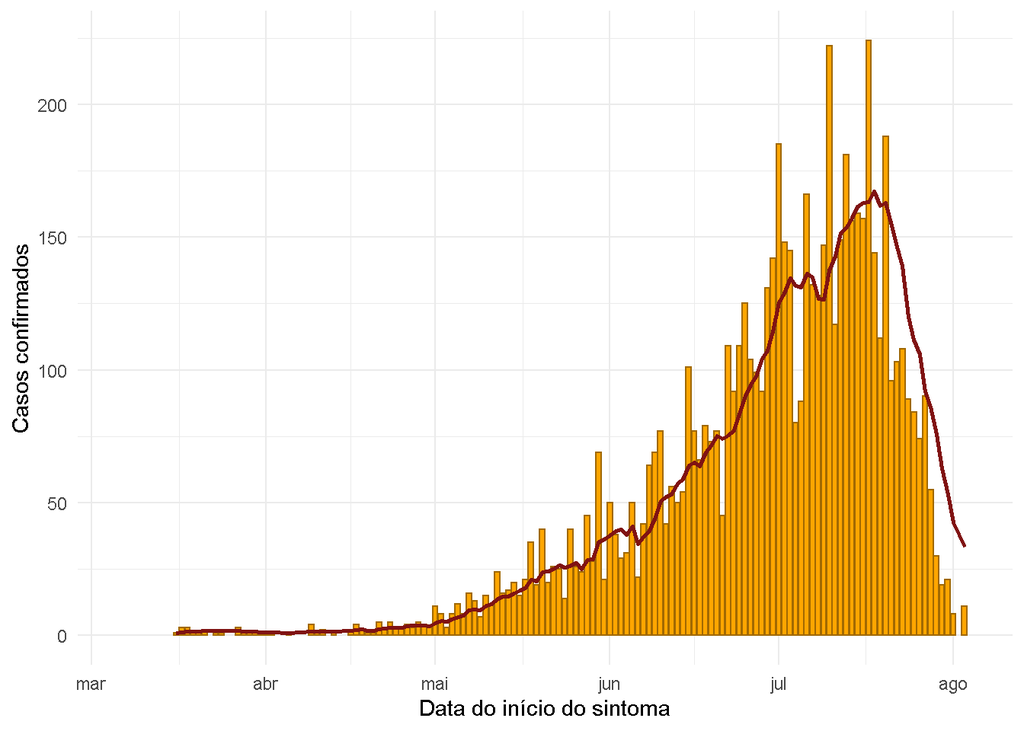

**Figura 13.** Óbitos por COVID-19, por semana epidemiológica, Nordeste da Bahia, 2020.

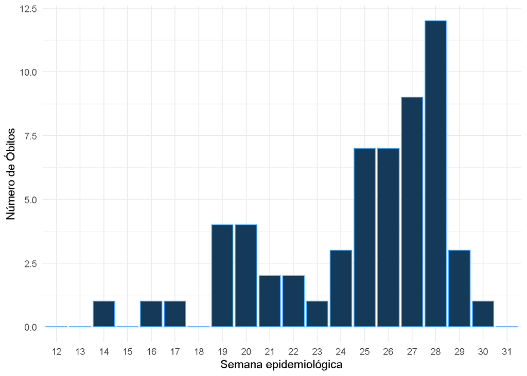

### **2.6 - Séries históricas do COVID-19 no Norte da Bahia**

**Figura 14.** Casos novos de COVID-19, por data de início de sintoma (e média móvel de 7 dias), Norte da Bahia, 2020.

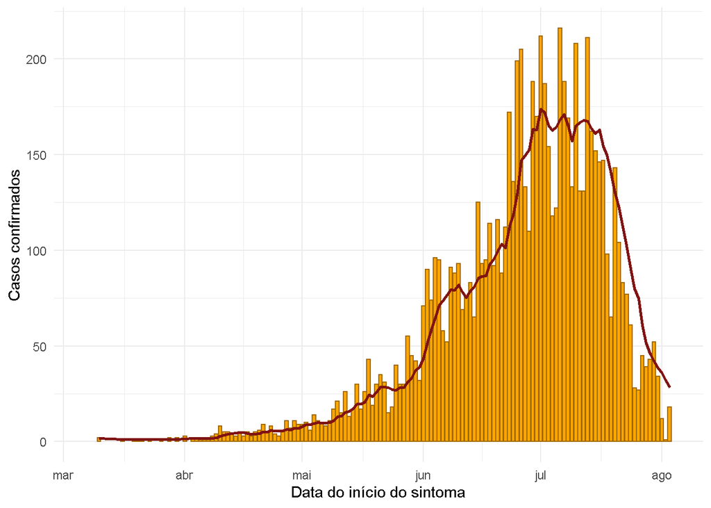

**Figura 15.** Óbitos por COVID-19, por semana epidemiológica, Norte da Bahia, 2020.

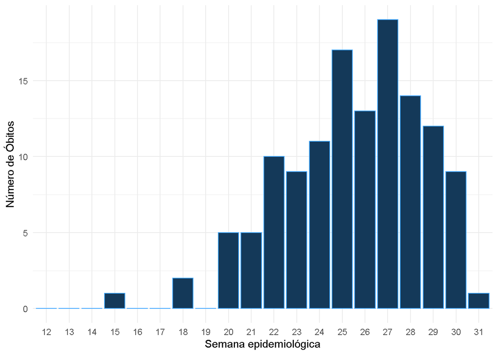

### **2.7 - Séries históricas do COVID-19 no Oeste da Bahia**

**Figura 16.** Casos novos de COVID-19, por data de início de sintoma (e média móvel de 7 dias), Oeste da Bahia, 2020.

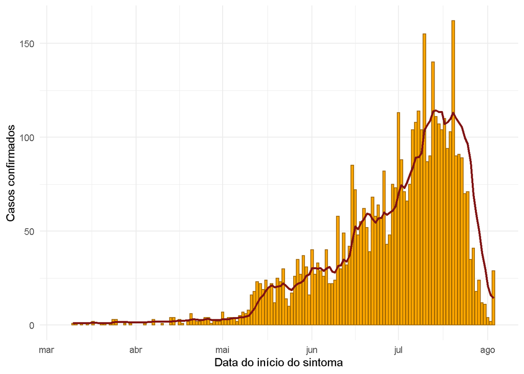

**Figura 17.** Óbitos por COVID-19, por semana epidemiológica, Oeste da Bahia, 2020.

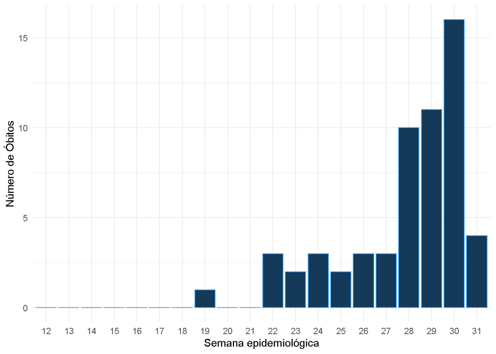

### **2.8 - Séries históricas do COVID-19 no Sudoeste da Bahia**

**Figura 18.** Casos novos de COVID-19, por data de início de sintoma (e média móvel de 7 dias), Sudoeste da Bahia, 2020.

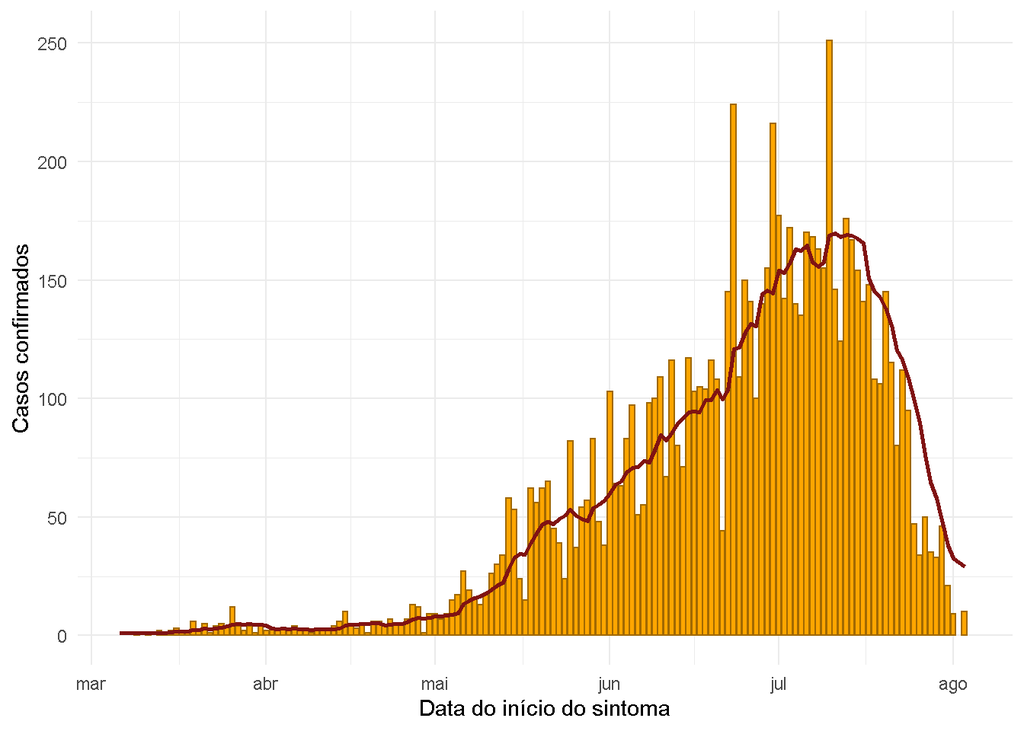

**Figura 19.** Óbitos por COVID-19, por semana epidemiológica, Sudoeste da Bahia, 2020.

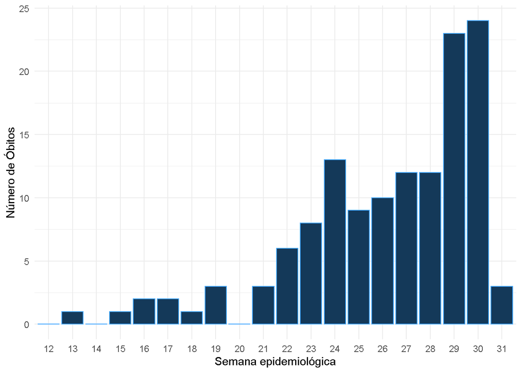

### **2.9 - Séries históricas do COVID-19 no Sul da Bahia**

**Figura 20.** Casos novos de COVID-19, por data de início de sintoma (e média móvel de 7 dias), Sul da Bahia, 2020.

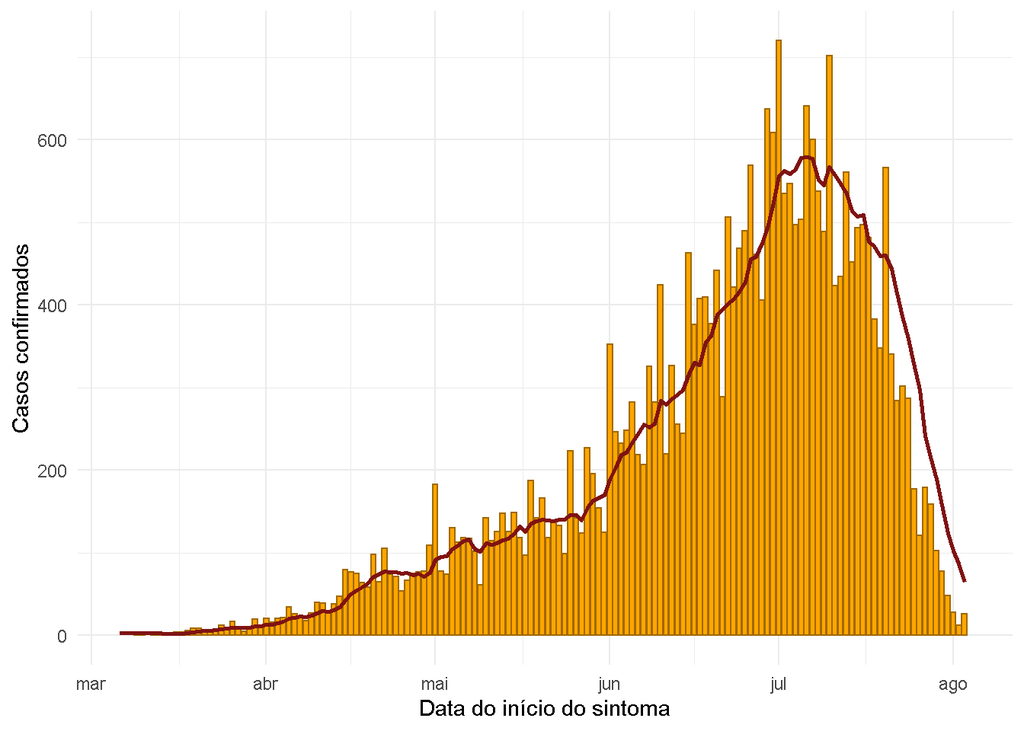

**Figura 21.** Óbitos por COVID-19, por semana epidemiológica, Sul da Bahia, 2020.

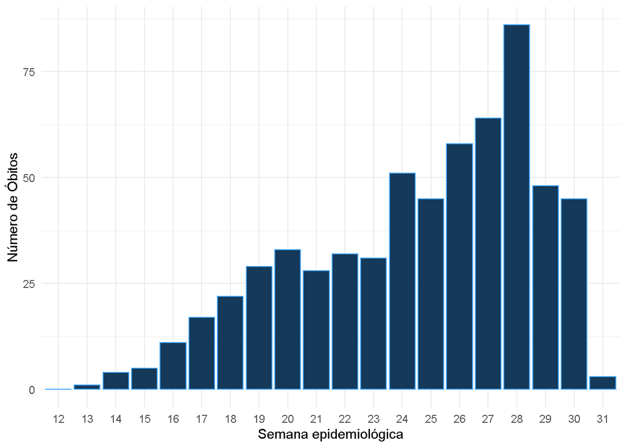